# Tables and figures in R

## Tables

There are a number of helpful tools for making nice tables, but as you’ve seen with the gapminder dataset, if you’re just writing an informal report you can just print the object you want to show and it’ll come out pretty neatly. Just to recap:

```r
gapminder
```

```
## # A tibble: 1,704 x 6
##        country continent  year lifeExp      pop gdpPercap
##         <fctr>    <fctr> <int>   <dbl>    <int>     <dbl>
##  1 Afghanistan      Asia  1952  28.801  8425333  779.4453
##  2 Afghanistan      Asia  1957  30.332  9240934  820.8530
##  3 Afghanistan      Asia  1962  31.997 10267083  853.1007
##  4 Afghanistan      Asia  1967  34.020 11537966  836.1971
##  5 Afghanistan      Asia  1972  36.088 13079460  739.9811
##  6 Afghanistan      Asia  1977  38.438 14880372  786.1134
##  7 Afghanistan      Asia  1982  39.854 12881816  978.0114
##  8 Afghanistan      Asia  1987  40.822 13867957  852.3959
##  9 Afghanistan      Asia  1992  41.674 16317921  649.3414
## 10 Afghanistan      Asia  1997  41.763 22227415  635.3414
## # ... with 1,694 more rows
```

Another option is `kable` from the `knitr` package.

```r
knitr::kable(head(gapminder)) # without head() will print out entire dataframe
```

| country | continent | year | lifeExp | pop | gdpPercap |
| --- | --- | --- | --- | --- | --- |
| Afghanistan | Asia | 1952 | 28.801 | 8425333 | 779.4453 |
| Afghanistan | Asia | 1957 | 30.332 | 9240934 | 820.8530 |
| Afghanistan | Asia | 1962 | 31.997 | 10267083 | 853.1007 |
| Afghanistan | Asia | 1967 | 34.020 | 11537966 | 836.1971 |
| Afghanistan | Asia | 1972 | 36.088 | 13079460 | 739.9811 |
| Afghanistan | Asia | 1977 | 38.438 | 14880372 | 786.1134 |

`stargazer` is probably your best option for making journal-quality tables. One of its main selling points is that can take regression output directly and convert that into your standard regression table. However, it has some idiosycrasies that can occasionally be inconvenient. Notice below how I have to specify `results = 'asis'` in the chunk options, and `type = "html"` in the function. The latter means that if I want to knit this document as a pdf instead then I have to change the stargazer options.

````
```{r, results = 'asis'}
toymodel = lm(lifeExp ~ gdpPercap, data = gapminder)

stargazer::stargazer(toymodel, type = "html", title = "Table with stargazer")
```
````

```r
toymodel = lm(lifeExp ~ gdpPercap, data = gapminder)

stargazer::stargazer(toymodel, type = "html", title = "Table with stargazer")
```

**Table with stargazer**

|  | *Dependent variable:* |
| --- | --- |
|  | lifeExp |
| gdpPercap | 0.001*** |
|  | (0.00003) |
| Constant | 53.956*** |
|  | (0.315) |
| Observations | 1,704 |
| R<sup>2</sup> | 0.341 |
| Adjusted R<sup>2</sup> | 0.340 |
| Residual Std. Error | 10.491 (df = 1702) |
| F Statistic | 879.577*** (df = 1; 1702) |
| *Note:* | p<0.1; p<0.05; p<0.01 |

`stargazer` has a ton of options that you can tweak. The [cheatsheet from Jake Russ (which you can see below)](http://www.jakeruss.com/cheatsheets/stargazer/) is super helpful.

[interactive chart not shown]

This is also a good opportunity to show you the `broom` package (by David Robinson) for working with regression output. This is one of my favorite packages in R. The `tidy` function converts your regression output into a data frame, making it extremely easy to work with. In particular, it becomes straightforward to plot your coefficients.

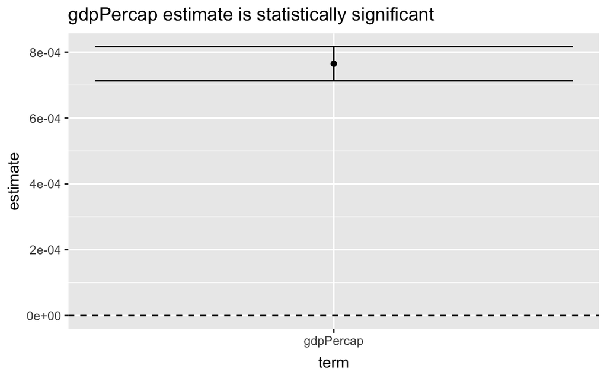

```r
toymodel_df = broom::tidy(toymodel)

ggplot(filter(toymodel_df, term == "gdpPercap"),
       aes(term, estimate, ymin = estimate - 2*std.error, ymax = estimate + 2*std.error)) +
  geom_point() + geom_errorbar() +
  geom_hline(yintercept = 0, linetype = 2) +
  ggtitle("gdpPercap estimate is statistically significant")
```

Of course, this isn’t a very helpful graph since there’s only one coefficient, but it’s easy to think of situations where it’d be super helpful e.g. event study with different estimates for each point in time.